# Risk Factor Analysis

## Outcome Variable

**Outcome Variable:** pers_wasted624

## Predictor Variables

**Intervention Variable:** ever_swasted06_noBW

**Adjustment Set:**

unadjusted

## Stratifying Variables

The analysis was stratified on these variable(s):

- studyid
- country

## Data Summary

| studyid | country | ever_swasted06_noBW | pers_wasted624 | n_cell | n |
| --- | --- | --- | --- | --- | --- |
| ki0047075b-MAL-ED | BANGLADESH | 0 | 0 | 216 | 238 |
| ki0047075b-MAL-ED | BANGLADESH | 0 | 1 | 15 | 238 |
| ki0047075b-MAL-ED | BANGLADESH | 1 | 0 | 4 | 238 |
| ki0047075b-MAL-ED | BANGLADESH | 1 | 1 | 3 | 238 |
| ki0047075b-MAL-ED | BRAZIL | 0 | 0 | 198 | 201 |
| ki0047075b-MAL-ED | BRAZIL | 0 | 1 | 1 | 201 |
| ki0047075b-MAL-ED | BRAZIL | 1 | 0 | 2 | 201 |
| ki0047075b-MAL-ED | BRAZIL | 1 | 1 | 0 | 201 |
| ki0047075b-MAL-ED | INDIA | 0 | 0 | 203 | 229 |
| ki0047075b-MAL-ED | INDIA | 0 | 1 | 21 | 229 |
| ki0047075b-MAL-ED | INDIA | 1 | 0 | 3 | 229 |
| ki0047075b-MAL-ED | INDIA | 1 | 1 | 2 | 229 |
| ki0047075b-MAL-ED | NEPAL | 0 | 0 | 230 | 232 |
| ki0047075b-MAL-ED | NEPAL | 0 | 1 | 1 | 232 |
| ki0047075b-MAL-ED | NEPAL | 1 | 0 | 1 | 232 |
| ki0047075b-MAL-ED | NEPAL | 1 | 1 | 0 | 232 |
| ki0047075b-MAL-ED | PERU | 0 | 0 | 261 | 264 |
| ki0047075b-MAL-ED | PERU | 0 | 1 | 2 | 264 |
| ki0047075b-MAL-ED | PERU | 1 | 0 | 1 | 264 |
| ki0047075b-MAL-ED | PERU | 1 | 1 | 0 | 264 |
| ki0047075b-MAL-ED | SOUTH AFRICA | 0 | 0 | 253 | 257 |
| ki0047075b-MAL-ED | SOUTH AFRICA | 0 | 1 | 1 | 257 |
| ki0047075b-MAL-ED | SOUTH AFRICA | 1 | 0 | 3 | 257 |
| ki0047075b-MAL-ED | SOUTH AFRICA | 1 | 1 | 0 | 257 |
| ki0047075b-MAL-ED | TANZANIA, UNITED REPUBLIC OF | 0 | 0 | 242 | 244 |
| ki0047075b-MAL-ED | TANZANIA, UNITED REPUBLIC OF | 0 | 1 | 0 | 244 |
| ki0047075b-MAL-ED | TANZANIA, UNITED REPUBLIC OF | 1 | 0 | 2 | 244 |
| ki0047075b-MAL-ED | TANZANIA, UNITED REPUBLIC OF | 1 | 1 | 0 | 244 |
| ki1000108-CMC-V-BCS-2002 | INDIA | 0 | 0 | 304 | 350 |
| ki1000108-CMC-V-BCS-2002 | INDIA | 0 | 1 | 16 | 350 |

[output cut: 118 more lines]

The following strata were considered:

- studyid: ki0047075b-MAL-ED, country: BANGLADESH
- studyid: ki0047075b-MAL-ED, country: BRAZIL
- studyid: ki0047075b-MAL-ED, country: INDIA
- studyid: ki0047075b-MAL-ED, country: NEPAL
- studyid: ki0047075b-MAL-ED, country: PERU
- studyid: ki0047075b-MAL-ED, country: SOUTH AFRICA
- studyid: ki0047075b-MAL-ED, country: TANZANIA, UNITED REPUBLIC OF
- studyid: ki1000108-CMC-V-BCS-2002, country: INDIA
- studyid: ki1000108-IRC, country: INDIA
- studyid: ki1000109-EE, country: PAKISTAN
- studyid: ki1000109-ResPak, country: PAKISTAN
- studyid: ki1000304-VITAMIN-A, country: INDIA
- studyid: ki1000304b-SAS-CompFeed, country: INDIA
- studyid: ki1000304b-SAS-FoodSuppl, country: INDIA
- studyid: ki1017093-NIH-Birth, country: BANGLADESH
- studyid: ki1017093b-PROVIDE, country: BANGLADESH
- studyid: ki1017093c-NIH-Crypto, country: BANGLADESH
- studyid: ki1066203-TanzaniaChild2, country: TANZANIA, UNITED REPUBLIC OF
- studyid: ki1101329-Keneba, country: GAMBIA
- studyid: ki1112895-Burkina Faso Zn, country: BURKINA FASO
- studyid: ki1112895-Guatemala BSC, country: GUATEMALA
- studyid: ki1113344-GMS-Nepal, country: NEPAL
- studyid: ki1114097-CMIN, country: BANGLADESH
- studyid: ki1114097-CMIN, country: BRAZIL
- studyid: ki1114097-CMIN, country: GUINEA-BISSAU
- studyid: ki1114097-CMIN, country: PERU
- studyid: ki1114097-CONTENT, country: PERU
- studyid: ki1119695-PROBIT, country: BELARUS
- studyid: ki1126311-ZVITAMBO, country: ZIMBABWE
- studyid: ki1135781-COHORTS, country: GUATEMALA
- studyid: ki1135781-COHORTS, country: INDIA
- studyid: ki1135781-COHORTS, country: PHILIPPINES
- studyid: ki1148112-iLiNS-DOSE, country: MALAWI
- studyid: ki1148112-iLiNS-DYAD-M, country: MALAWI
- studyid: ki1148112-LCNI-5, country: MALAWI
- studyid: kiGH5241-JiVitA-3, country: BANGLADESH
- studyid: kiGH5241-JiVitA-4, country: BANGLADESH

### Dropped Strata

Some strata were dropped due to rare outcomes:

- studyid: ki0047075b-MAL-ED, country: BANGLADESH
- studyid: ki0047075b-MAL-ED, country: BRAZIL
- studyid: ki0047075b-MAL-ED, country: INDIA
- studyid: ki0047075b-MAL-ED, country: NEPAL
- studyid: ki0047075b-MAL-ED, country: PERU
- studyid: ki0047075b-MAL-ED, country: SOUTH AFRICA
- studyid: ki0047075b-MAL-ED, country: TANZANIA, UNITED REPUBLIC OF
- studyid: ki1000304-VITAMIN-A, country: INDIA
- studyid: ki1000304b-SAS-FoodSuppl, country: INDIA
- studyid: ki1017093-NIH-Birth, country: BANGLADESH
- studyid: ki1017093b-PROVIDE, country: BANGLADESH
- studyid: ki1017093c-NIH-Crypto, country: BANGLADESH
- studyid: ki1112895-Burkina Faso Zn, country: BURKINA FASO
- studyid: ki1112895-Guatemala BSC, country: GUATEMALA
- studyid: ki1114097-CMIN, country: BANGLADESH
- studyid: ki1114097-CMIN, country: BRAZIL
- studyid: ki1114097-CMIN, country: GUINEA-BISSAU
- studyid: ki1114097-CMIN, country: PERU
- studyid: ki1114097-CONTENT, country: PERU
- studyid: ki1119695-PROBIT, country: BELARUS
- studyid: ki1135781-COHORTS, country: GUATEMALA
- studyid: ki1148112-iLiNS-DOSE, country: MALAWI
- studyid: ki1148112-iLiNS-DYAD-M, country: MALAWI
- studyid: ki1148112-LCNI-5, country: MALAWI

## Methods Detail

We’re interested in the causal parameters $E[Y_a]$ for all values of $a \in \mathcal{A}$. These parameters represent the mean outcome if, possibly contrary to fact, we intervened to set all units to have $A=a$. Under the randomization and positivity assumptions, these are identified by the statistical parameters $\psi_a=E_W[E_{Y|A,W}(Y|A=a,W)]$. In addition, we’re interested in the mean of $Y$, $E[Y]$ under no intervention (the observed mean). We will estimate these parameters by using SuperLearner to fit the relevant likelihood factors – $E_{Y|A,W}(Y|A=a,W)$ and $p(A=a|W)$, and then updating our likelihood fit using a joint TMLE.

For unadjusted analyses ($W=\{\}$), initial likelihoods were estimated using Lrnr_glm to estimate the simple $E(Y|A)$ and Lrnr_mean to estimate $p(A)$. For adjusted analyses, a small library containing Lrnr_glmnet, Lrnr_xgboost, and Lrnr_mean was used.

Having estimated these parameters, we will then use the delta method to estimate relative risks and attributable risks relative to a prespecified baseline level of $A$.

# Results Detail

## Results Plots

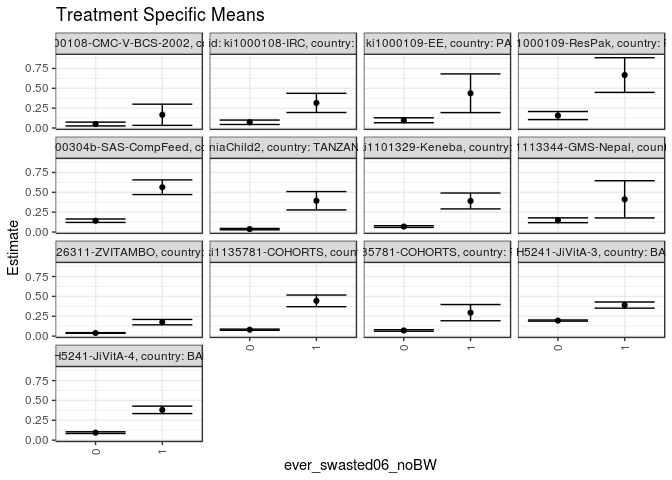

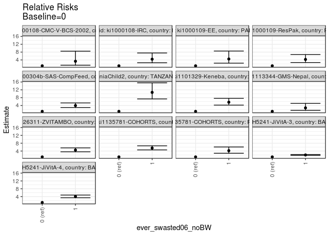

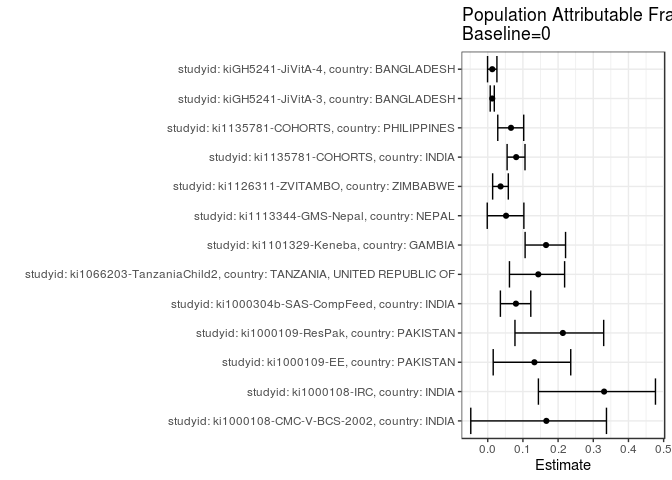

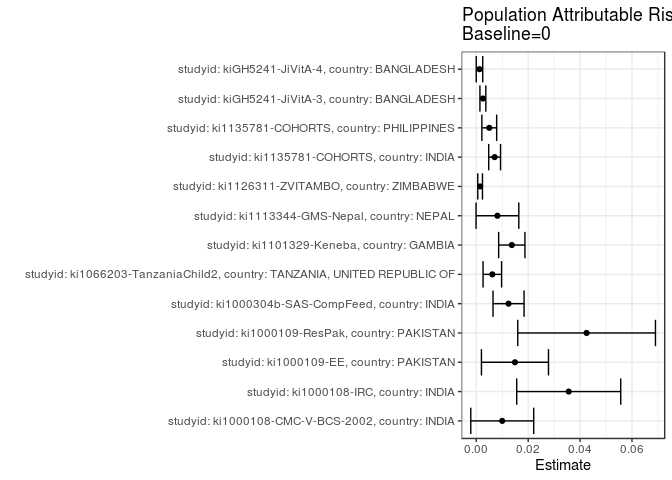

## Results Table

### Parameter: TSM

| studyid | country | intervention_level | baseline_level | estimate | ci_lower | ci_upper |
| --- | --- | --- | --- | --- | --- | --- |
| ki1000108-CMC-V-BCS-2002 | INDIA | 0 | NA | 0.0500000 | 0.0260866 | 0.0739134 |
| ki1000108-CMC-V-BCS-2002 | INDIA | 1 | NA | 0.1666667 | 0.0331171 | 0.3002162 |
| ki1000108-IRC | INDIA | 0 | NA | 0.0720721 | 0.0442606 | 0.0998836 |
| ki1000108-IRC | INDIA | 1 | NA | 0.3157895 | 0.1949631 | 0.4366159 |
| ki1000109-EE | PAKISTAN | 0 | NA | 0.0974212 | 0.0662682 | 0.1285742 |
| ki1000109-EE | PAKISTAN | 1 | NA | 0.4375000 | 0.1940924 | 0.6809076 |
| ki1000109-ResPak | PAKISTAN | 0 | NA | 0.1565657 | 0.1058319 | 0.2072994 |
| ki1000109-ResPak | PAKISTAN | 1 | NA | 0.6666667 | 0.4483870 | 0.8849463 |
| ki1000304b-SAS-CompFeed | INDIA | 0 | NA | 0.1425234 | 0.1208664 | 0.1641803 |
| ki1000304b-SAS-CompFeed | INDIA | 1 | NA | 0.5641026 | 0.4719219 | 0.6562832 |
| ki1066203-TanzaniaChild2 | TANZANIA, UNITED REPUBLIC OF | 0 | NA | 0.0368393 | 0.0282391 | 0.0454395 |
| ki1066203-TanzaniaChild2 | TANZANIA, UNITED REPUBLIC OF | 1 | NA | 0.3939394 | 0.2784535 | 0.5094253 |
| ki1101329-Keneba | GAMBIA | 0 | NA | 0.0689157 | 0.0580140 | 0.0798173 |
| ki1101329-Keneba | GAMBIA | 1 | NA | 0.3913043 | 0.2915546 | 0.4910541 |
| ki1113344-GMS-Nepal | NEPAL | 0 | NA | 0.1482176 | 0.1180255 | 0.1784098 |
| ki1113344-GMS-Nepal | NEPAL | 1 | NA | 0.4117647 | 0.1776014 | 0.6459280 |
| ki1126311-ZVITAMBO | ZIMBABWE | 0 | NA | 0.0391378 | 0.0349060 | 0.0433695 |
| ki1126311-ZVITAMBO | ZIMBABWE | 1 | NA | 0.1758242 | 0.1419099 | 0.2097385 |
| ki1135781-COHORTS | INDIA | 0 | NA | 0.0802920 | 0.0729634 | 0.0876206 |
| ki1135781-COHORTS | INDIA | 1 | NA | 0.4433962 | 0.3698004 | 0.5169920 |
| ki1135781-COHORTS | PHILIPPINES | 0 | NA | 0.0706542 | 0.0609149 | 0.0803935 |
| ki1135781-COHORTS | PHILIPPINES | 1 | NA | 0.2950820 | 0.1929934 | 0.3971705 |
| kiGH5241-JiVitA-3 | BANGLADESH | 0 | NA | 0.1951786 | 0.1876119 | 0.2027454 |
| kiGH5241-JiVitA-3 | BANGLADESH | 1 | NA | 0.3901099 | 0.3512180 | 0.4290018 |
| kiGH5241-JiVitA-4 | BANGLADESH | 0 | NA | 0.0942505 | 0.0835755 | 0.1049255 |
| kiGH5241-JiVitA-4 | BANGLADESH | 1 | NA | 0.3809524 | 0.3339979 | 0.4279069 |

### Parameter: E(Y)

| studyid | country | intervention_level | baseline_level | estimate | ci_lower | ci_upper |
| --- | --- | --- | --- | --- | --- | --- |
| ki1000108-CMC-V-BCS-2002 | INDIA | NA | NA | 0.0600000 | 0.0350842 | 0.0849158 |
| ki1000108-IRC | INDIA | NA | NA | 0.1076923 | 0.0768872 | 0.1384974 |
| ki1000109-EE | PAKISTAN | NA | NA | 0.1123288 | 0.0798897 | 0.1447679 |
| ki1000109-ResPak | PAKISTAN | NA | NA | 0.1990741 | 0.1456997 | 0.2524484 |
| ki1000304b-SAS-CompFeed | INDIA | NA | NA | 0.1549509 | 0.1362795 | 0.1736222 |
| ki1066203-TanzaniaChild2 | TANZANIA, UNITED REPUBLIC OF | NA | NA | 0.0430220 | 0.0339104 | 0.0521337 |
| ki1101329-Keneba | GAMBIA | NA | NA | 0.0826027 | 0.0710097 | 0.0941956 |
| ki1113344-GMS-Nepal | NEPAL | NA | NA | 0.1563636 | 0.1259823 | 0.1867450 |
| ki1126311-ZVITAMBO | ZIMBABWE | NA | NA | 0.0406194 | 0.0363964 | 0.0448425 |
| ki1135781-COHORTS | INDIA | NA | NA | 0.0873555 | 0.0798578 | 0.0948531 |
| ki1135781-COHORTS | PHILIPPINES | NA | NA | 0.0756579 | 0.0657470 | 0.0855688 |
| kiGH5241-JiVitA-3 | BANGLADESH | NA | NA | 0.1977211 | 0.1902810 | 0.2051611 |
| kiGH5241-JiVitA-4 | BANGLADESH | NA | NA | 0.0954815 | 0.0850302 | 0.1059328 |

### Parameter: RR

| studyid | country | intervention_level | baseline_level | estimate | ci_lower | ci_upper |
| --- | --- | --- | --- | --- | --- | --- |
| ki1000108-CMC-V-BCS-2002 | INDIA | 0 | 0 | 1.000000 | 1.000000 | 1.000000 |
| ki1000108-CMC-V-BCS-2002 | INDIA | 1 | 0 | 3.333333 | 1.311008 | 8.475240 |
| ki1000108-IRC | INDIA | 0 | 0 | 1.000000 | 1.000000 | 1.000000 |
| ki1000108-IRC | INDIA | 1 | 0 | 4.381579 | 2.544647 | 7.544558 |
| ki1000109-EE | PAKISTAN | 0 | 0 | 1.000000 | 1.000000 | 1.000000 |
| ki1000109-EE | PAKISTAN | 1 | 0 | 4.490809 | 2.363920 | 8.531323 |
| ki1000109-ResPak | PAKISTAN | 0 | 0 | 1.000000 | 1.000000 | 1.000000 |
| ki1000109-ResPak | PAKISTAN | 1 | 0 | 4.258064 | 2.686277 | 6.749533 |
| ki1000304b-SAS-CompFeed | INDIA | 0 | 0 | 1.000000 | 1.000000 | 1.000000 |
| ki1000304b-SAS-CompFeed | INDIA | 1 | 0 | 3.957965 | 2.960535 | 5.291439 |
| ki1066203-TanzaniaChild2 | TANZANIA, UNITED REPUBLIC OF | 0 | 0 | 1.000000 | 1.000000 | 1.000000 |
| ki1066203-TanzaniaChild2 | TANZANIA, UNITED REPUBLIC OF | 1 | 0 | 10.693456 | 7.351307 | 15.555057 |
| ki1101329-Keneba | GAMBIA | 0 | 0 | 1.000000 | 1.000000 | 1.000000 |
| ki1101329-Keneba | GAMBIA | 1 | 0 | 5.678018 | 4.206338 | 7.664596 |
| ki1113344-GMS-Nepal | NEPAL | 0 | 0 | 1.000000 | 1.000000 | 1.000000 |
| ki1113344-GMS-Nepal | NEPAL | 1 | 0 | 2.778109 | 1.518474 | 5.082661 |
| ki1126311-ZVITAMBO | ZIMBABWE | 0 | 0 | 1.000000 | 1.000000 | 1.000000 |
| ki1126311-ZVITAMBO | ZIMBABWE | 1 | 0 | 4.492443 | 3.601213 | 5.604234 |
| ki1135781-COHORTS | INDIA | 0 | 0 | 1.000000 | 1.000000 | 1.000000 |
| ki1135781-COHORTS | INDIA | 1 | 0 | 5.522298 | 4.569351 | 6.673984 |
| ki1135781-COHORTS | PHILIPPINES | 0 | 0 | 1.000000 | 1.000000 | 1.000000 |
| ki1135781-COHORTS | PHILIPPINES | 1 | 0 | 4.176425 | 2.877838 | 6.060982 |
| kiGH5241-JiVitA-3 | BANGLADESH | 0 | 0 | 1.000000 | 1.000000 | 1.000000 |
| kiGH5241-JiVitA-3 | BANGLADESH | 1 | 0 | 1.998733 | 1.794197 | 2.226585 |
| kiGH5241-JiVitA-4 | BANGLADESH | 0 | 0 | 1.000000 | 1.000000 | 1.000000 |
| kiGH5241-JiVitA-4 | BANGLADESH | 1 | 0 | 4.041913 | 3.415745 | 4.782869 |

### Parameter: PAR

| studyid | country | intervention_level | baseline_level | estimate | ci_lower | ci_upper |
| --- | --- | --- | --- | --- | --- | --- |
| ki1000108-CMC-V-BCS-2002 | INDIA | 0 | NA | 0.0100000 | -0.0021235 | 0.0221235 |
| ki1000108-IRC | INDIA | 0 | NA | 0.0356202 | 0.0155810 | 0.0556595 |
| ki1000109-EE | PAKISTAN | 0 | NA | 0.0149076 | 0.0019897 | 0.0278254 |
| ki1000109-ResPak | PAKISTAN | 0 | NA | 0.0425084 | 0.0159775 | 0.0690393 |
| ki1000304b-SAS-CompFeed | INDIA | 0 | NA | 0.0124275 | 0.0064491 | 0.0184059 |
| ki1066203-TanzaniaChild2 | TANZANIA, UNITED REPUBLIC OF | 0 | NA | 0.0061827 | 0.0026111 | 0.0097544 |
| ki1101329-Keneba | GAMBIA | 0 | NA | 0.0136870 | 0.0086232 | 0.0187508 |
| ki1113344-GMS-Nepal | NEPAL | 0 | NA | 0.0081460 | -0.0000889 | 0.0163809 |
| ki1126311-ZVITAMBO | ZIMBABWE | 0 | NA | 0.0014817 | 0.0005752 | 0.0023881 |
| ki1135781-COHORTS | INDIA | 0 | NA | 0.0070635 | 0.0047849 | 0.0093421 |
| ki1135781-COHORTS | PHILIPPINES | 0 | NA | 0.0050037 | 0.0021550 | 0.0078524 |
| kiGH5241-JiVitA-3 | BANGLADESH | 0 | NA | 0.0025425 | 0.0014060 | 0.0036789 |
| kiGH5241-JiVitA-4 | BANGLADESH | 0 | NA | 0.0012310 | -0.0000152 | 0.0024772 |

### Parameter: PAF

| studyid | country | intervention_level | baseline_level | estimate | ci_lower | ci_upper |
| --- | --- | --- | --- | --- | --- | --- |
| ki1000108-CMC-V-BCS-2002 | INDIA | 0 | NA | 0.1666667 | -0.0482113 | 0.3374957 |
| ki1000108-IRC | INDIA | 0 | NA | 0.3307593 | 0.1440478 | 0.4767429 |
| ki1000109-EE | PAKISTAN | 0 | NA | 0.1327137 | 0.0155440 | 0.2359378 |
| ki1000109-ResPak | PAKISTAN | 0 | NA | 0.2135307 | 0.0773932 | 0.3295800 |
| ki1000304b-SAS-CompFeed | INDIA | 0 | NA | 0.0802029 | 0.0359898 | 0.1223882 |
| ki1066203-TanzaniaChild2 | TANZANIA, UNITED REPUBLIC OF | 0 | NA | 0.1437110 | 0.0617618 | 0.2185024 |
| ki1101329-Keneba | GAMBIA | 0 | NA | 0.1656970 | 0.1062414 | 0.2211974 |
| ki1113344-GMS-Nepal | NEPAL | 0 | NA | 0.0520965 | -0.0013884 | 0.1027247 |
| ki1126311-ZVITAMBO | ZIMBABWE | 0 | NA | 0.0364764 | 0.0139487 | 0.0584895 |
| ki1135781-COHORTS | INDIA | 0 | NA | 0.0808594 | 0.0550683 | 0.1059465 |
| ki1135781-COHORTS | PHILIPPINES | 0 | NA | 0.0661357 | 0.0285190 | 0.1022958 |
| kiGH5241-JiVitA-3 | BANGLADESH | 0 | NA | 0.0128588 | 0.0070563 | 0.0186275 |
| kiGH5241-JiVitA-4 | BANGLADESH | 0 | NA | 0.0128924 | -0.0004948 | 0.0261005 |